# Limiting Distributions

Nikolai Lipscomb

October 21, 2019

## Limiting Distributions of Statistics

We recall one of our most elementary statistics, the sample mean: $\bar{x} = \frac{\sum_{i=1}^n x_i}{n}$.

We know that when a simple random sample of size n is drawn from a $N(\mu, \sigma)$ distribution, the associated sample mean $\bar{x}$ is essentially drawn from a $N(\mu, \frac{\sigma}{\sqrt{n}})$ distribution.

Let us see this in action by generating multiple samples of a set size n, then plotting the associated histogram. We will use $\mu = 10$ and $\sigma = 20$.

First let us construct the population distribution by considering samples of size n=1. We will demonstrate how a histogram converges to a distribution as we create more and more data, allowing us to shrink histogram class sizes.

If we only generate 100 datapoints, but use very fine bin sizes, this is what we get…

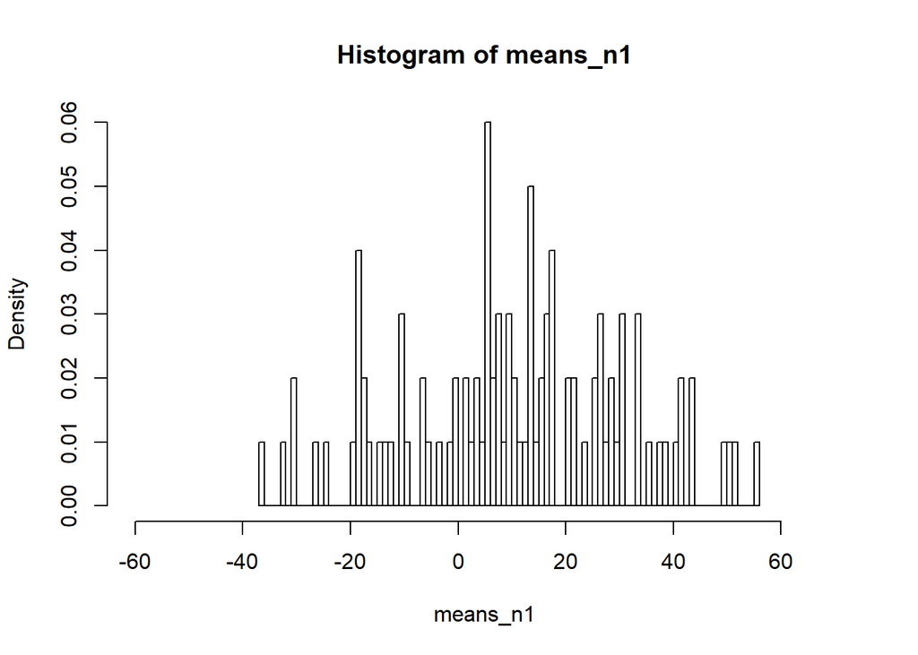

```r
library(ggplot2)
num_samples = 100
means_n1 = matrix(0,num_samples,0)
for (i in 1:num_samples){
  means_n1[i] = rnorm(1,10,20)
}
hist(means_n1, prob=T, breaks=100, xlim=c(-60,70))
```

Not very nice, right? Let’s try 100 again but with bigger binwidth.

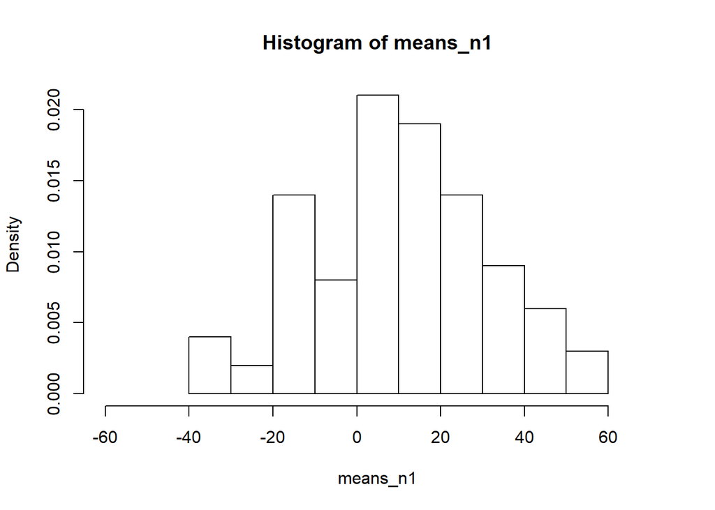

```r
hist(means_n1, prob=T, breaks=10, xlim=c(-60,70))
```

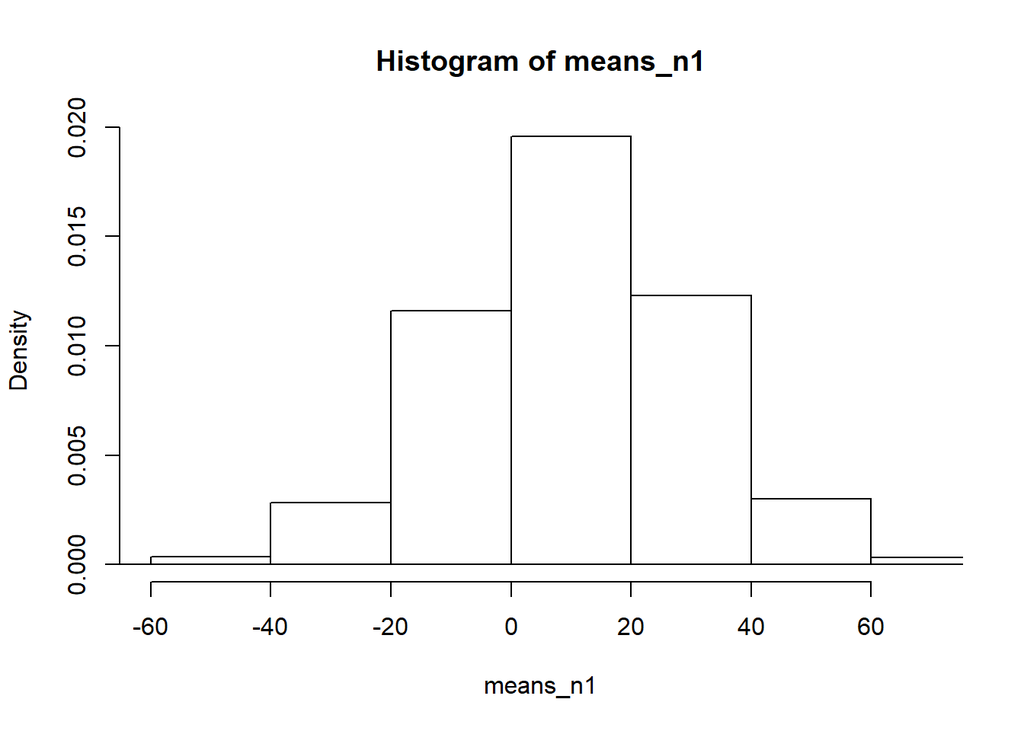

```r
num_samples = 10000
means_n1 = matrix(0,num_samples,0)
for (i in 1:num_samples){
  means_n1[i] = rnorm(1,10,20)
}
hist(means_n1, prob=T, breaks=10, xlim=c(-60,70))
```

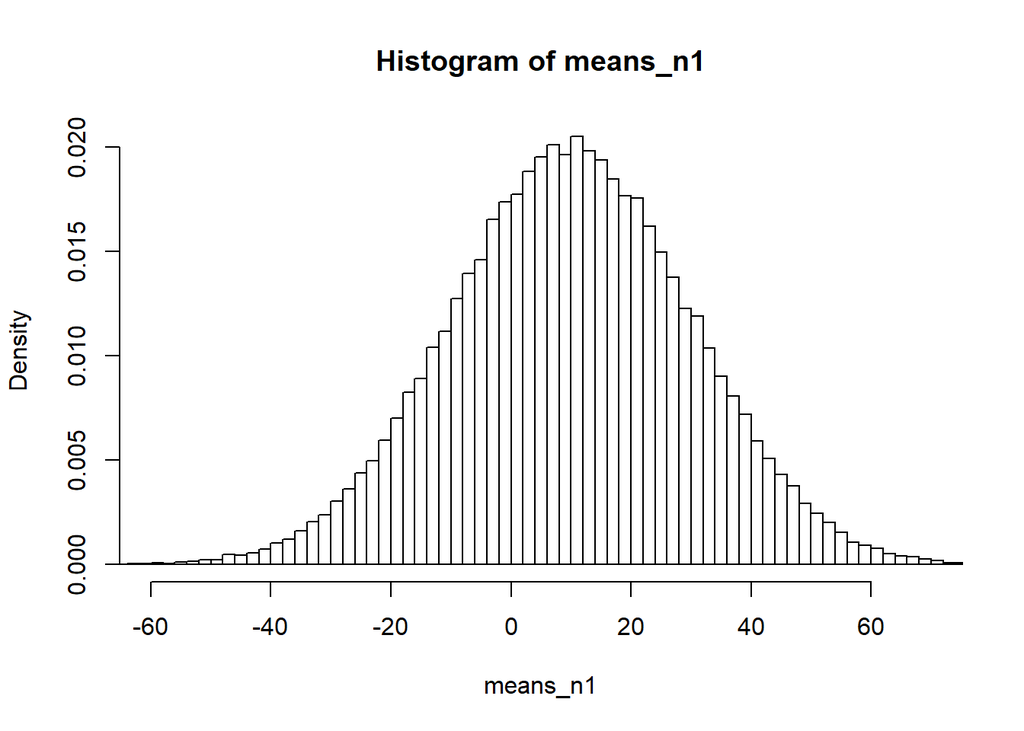

```r
num_samples = 100000
means_n1 = matrix(0,num_samples,0)
for (i in 1:num_samples){
  means_n1[i] = rnorm(1,10,20)
}
hist(means_n1, prob=T, breaks=100, xlim=c(-60,70))
```

This is starting to look more like a “theoretical” distribution. Kind in mind that as $n \rightarrow \infty$, we can let $binwidth \rightarrow 0^+$ which will lead to a smooth-looking curve. This justifies the idea of distributions representing a population.

Now we will use the same distribution, but generate means of sample sizes greater than 1. Let’s consider $n=4$ and compare it to the histogram just above. From our theoretical understand of the distribution of $\bar{x}$, the standard deviation should be $\frac{1}{2}$ of what is shown above.

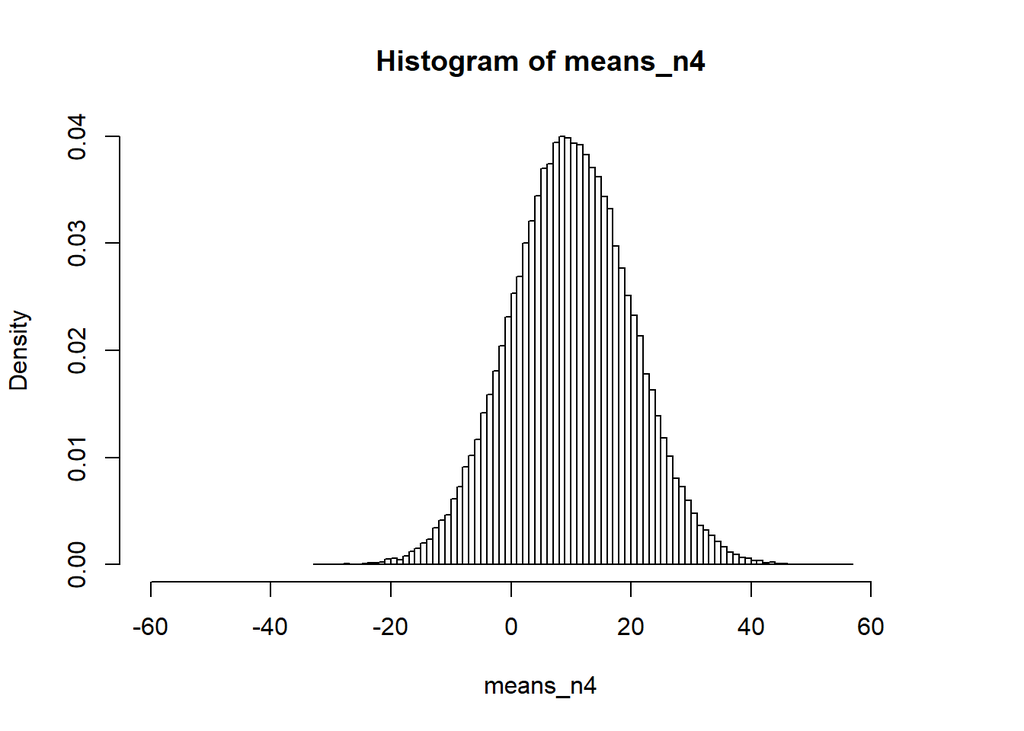

```r
num_samples = 100000
means_n4 = matrix(0,num_samples,0)
for (i in 1:num_samples){
  means_n4[i] = mean(rnorm(4,10,20))
}
hist(means_n4, prob=T, breaks=100, xlim=c(-60,70))
```

Are we convinced the standard deviation is half?

What if we let $n=25$, then we should have $\frac{1}{5}$ the standard deviation of the original.

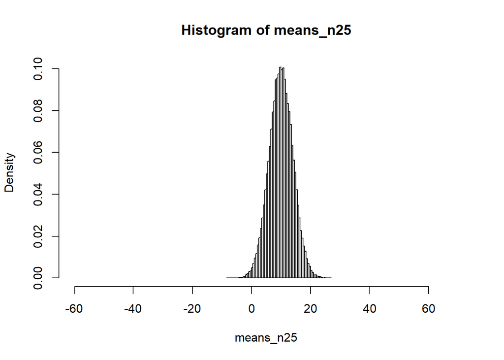

```r
num_samples = 100000
means_n25 = matrix(0,num_samples,0)
for (i in 1:num_samples){
  means_n25[i] = mean(rnorm(25,10,20))
}
hist(means_n25, prob=T, breaks=100, xlim=c(-60,70))
```

# Central Limit Theorem

We will demonstrate the central limit theorem in action by sampling from a different parametric, but non-normal distribution that has skew. We will let $X \thicksim exp(\lambda)$ where the expectation (mean) of $X$ given this distribution is $\mu_{X} = \frac{1}{\lambda}$. We will let $\lambda = 0.1$ so the expectation (mean) is 10. It is important to note that an exponential random variable will only take on positive values!

First, we will plot the “population” distribution by letting $n=1$.

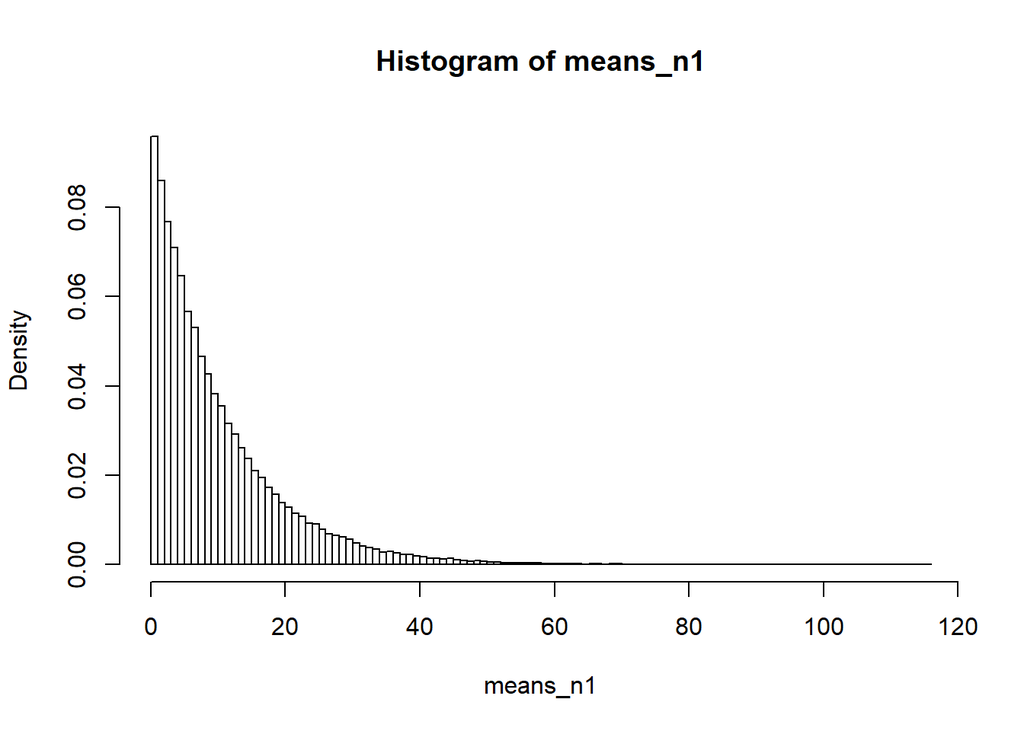

```r
num_samples = 100000
means_n1 = matrix(0,num_samples,0)
for (i in 1:num_samples){
  means_n1[i] = mean(rexp(1, rate=0.1))
}
hist(means_n1, prob=T, breaks = 100)
```

Let us try $n=4$.

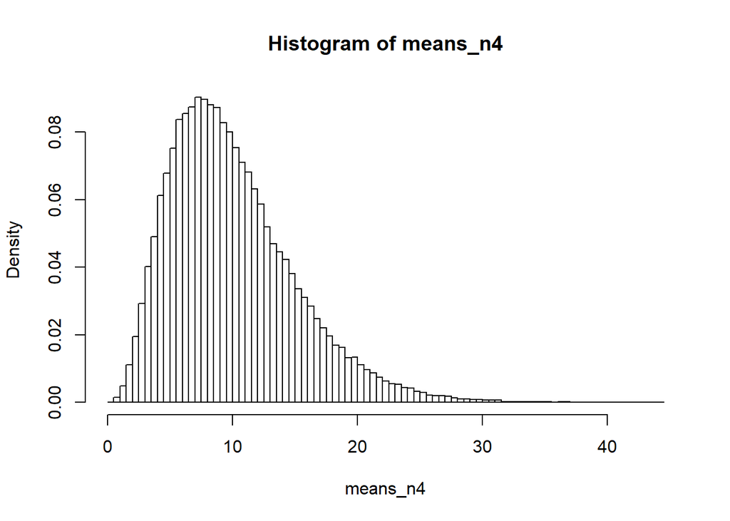

```r
num_samples = 100000
means_n4 = matrix(0,num_samples,0)
for (i in 1:num_samples){
  means_n4[i] = mean(rexp(4, rate=0.1))
}
hist(means_n4, prob=T, breaks = 100)
```

Okay, the data is still skewed, but significantly less so. What about $n=9$?

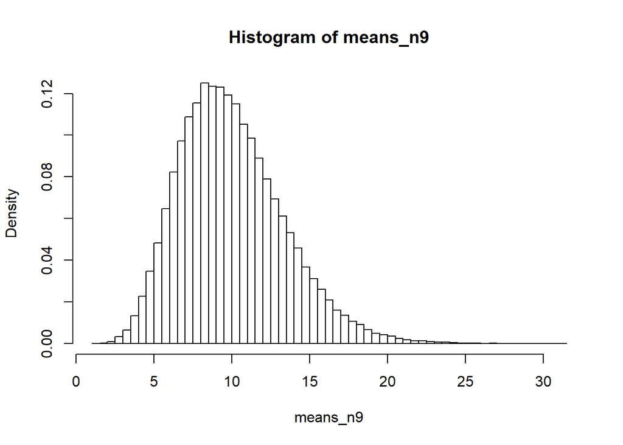

```r
num_samples = 100000
means_n9 = matrix(0,num_samples,0)
for (i in 1:num_samples){
  means_n9[i] = mean(rexp(9, rate=0.1))
}
hist(means_n9, prob=T, breaks = 100)
```

$n=25$?

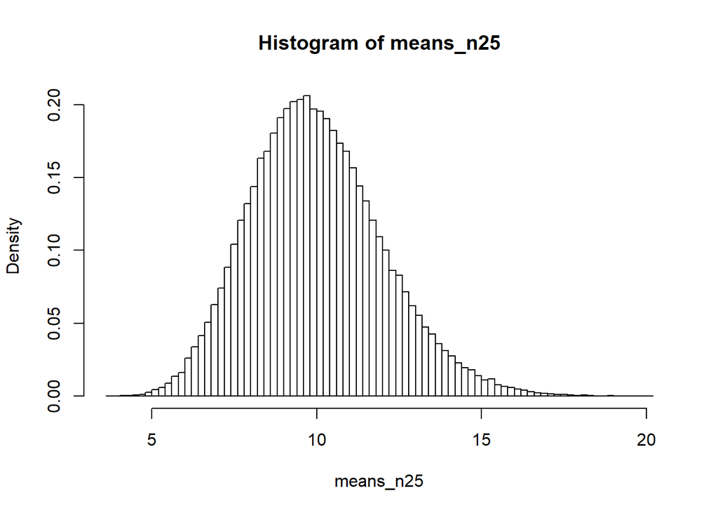

```r
num_samples = 100000
means_n25 = matrix(0,num_samples,0)
for (i in 1:num_samples){
  means_n25[i] = mean(rexp(25, rate=0.1))
}
hist(means_n25, prob=T, breaks = 100)
```

Let’s now plot a histogram of repeated sample means drawn from an exponential distribution against an actual plot of the normal distribution.

Let us note: for $X \thicksim exp(\lambda)$, we have $\mu_X = \frac{1}{\lambda}$ and $\sigma_X = \frac{1}{\lambda}$. We will use $n=100$.

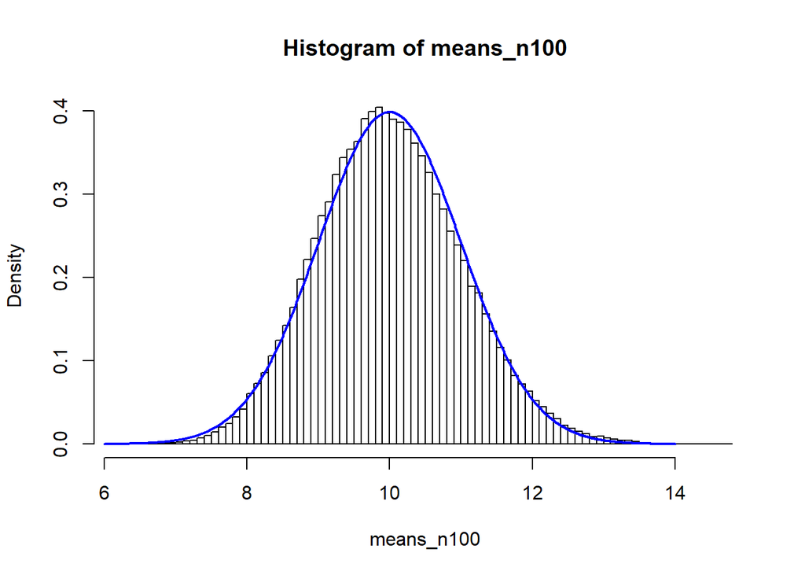

```r
num_samples = 100000
means_n100 = matrix(0,num_samples,0)
for (i in 1:num_samples){
  means_n100[i] = mean(rexp(100, rate=0.1))
}
hist(means_n100, prob=T, breaks = 100)
x <- seq(from=6, to=14, length.out=1000)
y <- dnorm(x, mean=10, sd=1, log=FALSE)
lines(x, y, col="blue", lwd=2)
```

Remember, the blue line is the actual density curve of a $N(\mu=10, \sigma=\frac{10}{\sqrt{100}}=1)$ random variable.